# STAT 545A Homework 6 Final Report

## Jinyuan Zhang

2013-10-19

- Introduction
- Description of Dataset
- Detect Outliers and Construct Clean Dataset
- Clean Data Analysis

### Introduction

Abalone, an excellent source of iron and pantothenic acid, is a nutritious food resource and farming in Australia, America and East Asia. 100 grams of abalone yields more than 20% recommended daily intake of these nutrients. The economic value of abalone is positively correlated with its age. Therefore, to detect the age of abalone accurately is important for both farmers and customers to determine its price. However, the current technology to decide the age is quite costly and inefficient. Farmers usually cut the shells and count the rings through microscopes to estimate the abalone¡¯s age. This complex method increases the cost and limits its popularity. Our target is to find out the best indicators to forecast the rings, then the age of abalones.

### Description of Dataset

Description of Dataset In this project, the data set Abalone is obtained from UCI Machine Learning Repository (1995). The data set contains physical measurements of 4177 abalones recorded in December 1995 by Marine Research Laboratories Taroona, Department of Primary Industry and Fisheries, Tasmania, Australia. There are nine variables, namely, Sex, Length, Diameter, and Height, Whole weight, Shucked weight, Viscera weight, Shell weight and Rings.The variable Rings is linearly related to the age of an abalone, as age equals to number of rings plus 1.5.

### Detect Outliers and Construct Clean Dataset

```r
library(ggplot2)
library(plyr)
library(nnet)
library(MASS)
library(gridExtra)
library(lattice)
library(RColorBrewer)
library(xtable)
Data = read.csv("abalone.csv")  # Import Data
print(str(Data))  # Structure of the Data
```

```
## 'data.frame':    4177 obs. of  9 variables:
##  $ Sex           : Factor w/ 3 levels "F","I","M": 3 3 1 3 2 2 1 1 3 1 ...
##  $ Length        : num  0.455 0.35 0.53 0.44 0.33 0.425 0.53 0.545 0.475 0.55 ...
##  $ Diameter      : num  0.365 0.265 0.42 0.365 0.255 0.3 0.415 0.425 0.37 0.44 ...
##  $ Height        : num  0.095 0.09 0.135 0.125 0.08 0.095 0.15 0.125 0.125 0.15 ...
##  $ Whole.weight  : num  0.514 0.226 0.677 0.516 0.205 ...
##  $ Shucked.weight: num  0.2245 0.0995 0.2565 0.2155 0.0895 ...
##  $ Viscera.weight: num  0.101 0.0485 0.1415 0.114 0.0395 ...
##  $ Shell.weight  : num  0.15 0.07 0.21 0.155 0.055 0.12 0.33 0.26 0.165 0.32 ...
##  $ Rings         : int  15 7 9 10 7 8 20 16 9 19 ...
## NULL
```

#### There are 4 different measures for weight i.e. Whole.weight, Shucked.weight, Viscera.weight and Shell.weight. And Whole.weight should be the easiest one to measure. So I drop out all the other measures.

```r
Data = subset(Data, select = -c(Shucked.weight, Viscera.weight, Shell.weight))
```

Plot number of abalone with different rings.

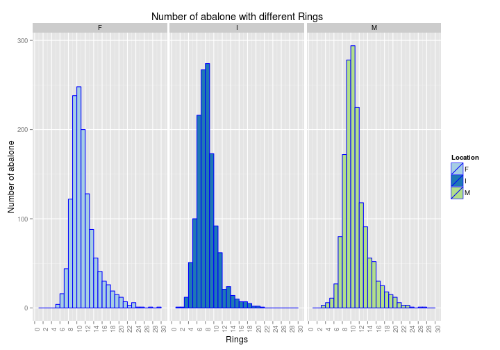

```r
ggplot(Data, aes(x = Rings, fill = Sex)) + geom_bar(binwidth = 1, color = "blue",
    origin = min(Data$Rings), position = "identity") + scale_x_continuous(name = "Rings",
    breaks = seq(0, 30, by = 2)) + theme(axis.text.x = element_text(angle = 90)) +
    scale_fill_brewer("Location", type = "qual", palette = 3) + ylab("Number of abalone") +
    ggtitle("Number of abalone with different Rings") + facet_wrap(~Sex, ncol = 3)
```

```r
Age = c(rep(0, nrow(Data)))
for (i in 1:nrow(Data)) {
    if (Data[i, ]$Rings < 7)
        Age[i] = 1
    if (Data[i, ]$Rings >= 7 & Data[i, ]$Rings <= 13)
        Age[i] = 2
    if (Data[i, ]$Rings > 13)
        Age[i] = 3
}
gData = cbind(Data, Age)
```

Roughly plot the graph and get little taste about data

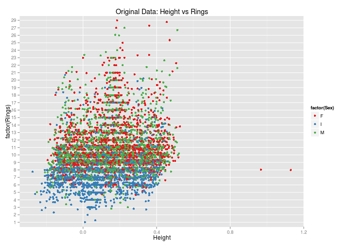

```r
ggplot(gData, aes(x = Height, y = factor(Rings), colour = factor(Sex))) + geom_jitter(position = position_jitter(width = 0.3)) +
    geom_point() + ggtitle("Original Data: Height vs Rings") + scale_colour_brewer(type = "seq",
    palette = "Set1")
```

#### From the graph above we can see that there are some outlines in Female. I want to get rid of them.

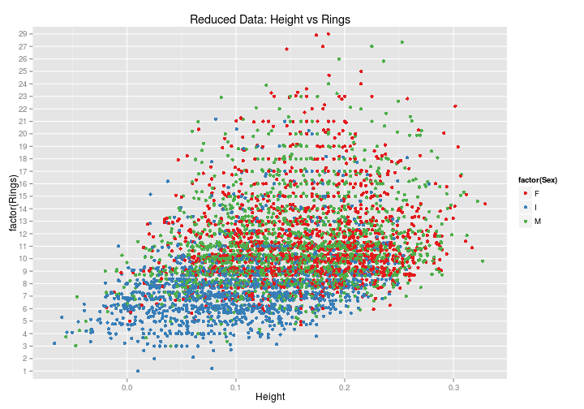

```r
jData = subset(gData, Height < 0.4)
ggplot(jData, aes(x = Height, y = factor(Rings), colour = factor(Sex))) + geom_jitter(position = position_jitter(width = 0.1)) +
    geom_point() + ggtitle("Reduced Data: Height vs Rings") + scale_colour_brewer(type = "seq",
    palette = "Set1")
```

#### Reorder data according to Sex and Rings

```r
Order_Data = arrange(jData, Sex, Rings, Length)
write.table(Order_Data, "abalone_clean.csv", quote = FALSE, sep = ",", row.names = FALSE)
```

### Clean Data Analysis

```r
Data = read.csv("abalone_clean.csv")  # Import Data
head(Data)
```

```
##   Sex Length Diameter Height Whole.weight Rings Age
## 1   F  0.275    0.195  0.070       0.0800     5   1
## 2   F  0.290    0.225  0.075       0.1400     5   1
## 3   F  0.360    0.270  0.090       0.1885     5   1
## 4   F  0.370    0.275  0.085       0.2405     5   1
## 5   F  0.290    0.210  0.075       0.2750     6   1
## 6   F  0.335    0.220  0.070       0.1700     6   1
```

Number of abalone of different Sex in different Age group.

```r
with(Data, table(Sex, Age))
```

```
##    Age
## Sex    1    2    3
##   F   20 1067  219
##   I  381  913   48
##   M   47 1257  223
```

#### First of all, I want to test whether Observation data like Height, Whole.weight can be helpful to decide the abalone to different Age group. Logistic regression is applied to do this analysis.

```
## geom_smooth: method="auto" and size of largest group is >=1000, so using gam with formula: y ~ s(x, bs = "cs"). Use 'method = x' to change the smoothing method.
```

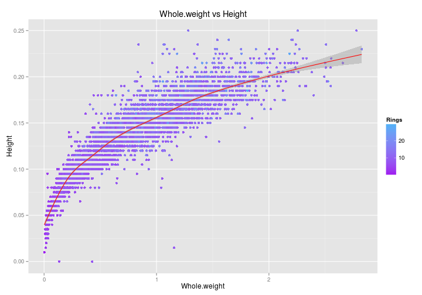

```r
ggplot(Data, aes(x = Whole.weight, y = Height)) + geom_point(aes(colour = Rings)) +
    scale_colour_gradient(low = "purple") + stat_smooth(colour = "red") + ggtitle("Whole.weight vs Height")
```

```
## geom_smooth: method="auto" and size of largest group is >=1000, so using gam with formula: y ~ s(x, bs = "cs"). Use 'method = x' to change the smoothing method.
```

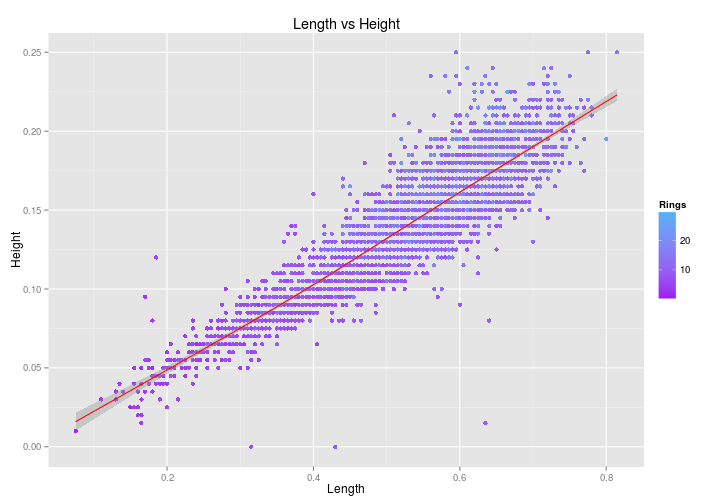

```r
ggplot(Data, aes(x = Length, y = Height)) + geom_point(aes(colour = Rings)) +
    scale_colour_gradient(low = "purple") + stat_smooth(colour = "red") + ggtitle("Length vs Height")
```

```
## geom_smooth: method="auto" and size of largest group is >=1000, so using gam with formula: y ~ s(x, bs = "cs"). Use 'method = x' to change the smoothing method.
```

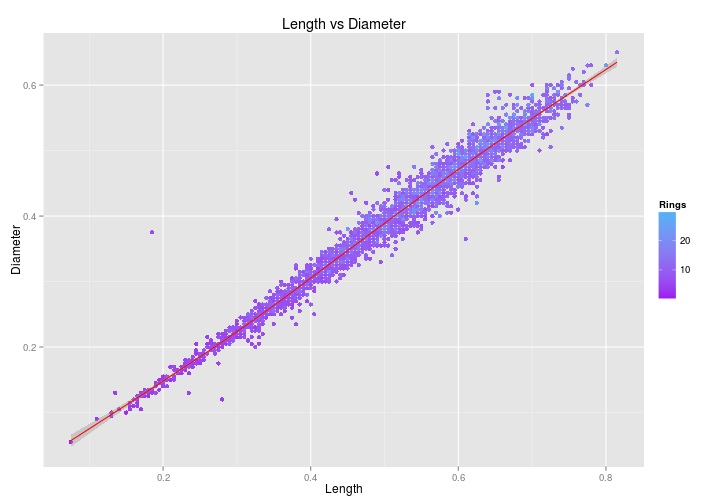

```r
ggplot(Data, aes(x = Length, y = Diameter)) + geom_point(aes(colour = Rings)) +
    scale_colour_gradient(low = "purple") + stat_smooth(colour = "red") + ggtitle("Length vs Diameter")
```

#### From above graphs, it is obvious that Length, Height and Diameter are relatively linear correlated. In fact, it is natural to think that the bigger the abalone, the heavier they are, so I want to check whether it is perfectly correlated between Whole.weight and Volume.

Construct Volume and Whole.weight dataset

```r
yData = ddply(Data, ~Sex + Age, summarize, Volume = Length * Diameter * Height,
    Whole.weight = Whole.weight, Rings = Rings)
```

Draw the point and regression lines

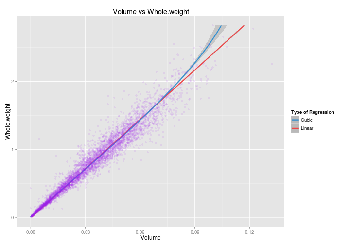

```r
cols <- c(Linear = "#f04546", Cubic = "#3591d1")
ggplot(data = yData, aes(x = Whole.weight, y = Volume)) + geom_smooth(method = "lm",
    aes(colour = "Linear"), lwd = 1) + geom_smooth(method = "lm", formula = y ~
    poly(x, 3), aes(colour = "Cubic"), lwd = 1) + geom_point(alpha = 1/10, colour = "purple") +
    scale_colour_manual("Type of Regression", values = cols) + ggtitle("Volume vs Whole.weight") +
    coord_flip() + scale_y_continuous(name = "Volume", breaks = seq(0, 0.15,
    by = 0.03))
```

#### From the graph above, it can be seen that Cubic regression and Linear regression is almost same in the beginning, but diverge when Volume is large, which means that Volume and Whole.weight is highly correlated for small abalone.

#### Why not just use Whole.weight to predict the Rings of abalone?

Calculate mean and variance of Whole.weight in different Sex.

```r
with(Data, do.call(rbind, tapply(Whole.weight, Sex, function(x) c(M = mean(x),
    SD = sd(x)))))
```

```
##        M     SD
## F 1.0469 0.4303
## I 0.4314 0.2863
## M 0.9907 0.4697
```

It seems that F and M are more heavier than I. Does that mean I group do not have large rings?

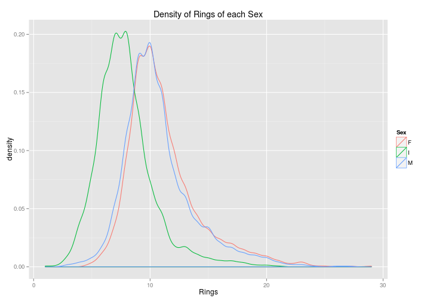

```r
ggplot(data = Data, aes(x = Rings, group = Sex, colour = Sex)) + geom_density() +
    ggtitle("Density of Rings of each Sex")
```

Sex I group abalone is younger than F and M group, but it do have old abalone with Sex I.

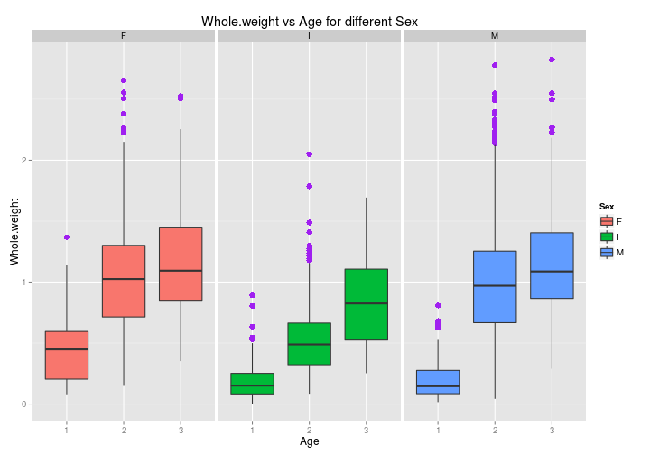

```r
ggplot(data = Data, aes(x = factor(Age), y = Whole.weight)) + geom_boxplot(outlier.colour = "purple",
    outlier.size = 3, aes(fill = Sex)) + facet_wrap(~Sex, ncol = 3) + ggtitle("Whole.weight vs Age for different Sex") +
    xlab("Age")
```

Compare to M and F, it seems that abalone with sex I have less weight.

#### Fit Multinational Regression Model

```r
logit <- multinom(Age ~ Whole.weight, data = yData)
summary(logit)
```

```
## Call:
## multinom(formula = Age ~ Whole.weight, data = yData)
##
## Coefficients:
##   (Intercept) Whole.weight
## 2      -1.826        9.362
## 3      -4.900       10.551
##
## Std. Errors:
##   (Intercept) Whole.weight
## 2      0.1353       0.4488
## 3      0.1781       0.4600
##
## Residual Deviance: 4177
## AIC: 4185
```

```r
pp = fitted(logit)
pred <- predict(logit)
table(pred, Data$Age)
```

```
##
## pred    1    2    3
##    1  268  108    0
##    2  180 3127  489
##    3    0    2    1
```

Construct a new dataset with information above.

```r
newdata = with(yData, data.frame(Weight = Whole.weight, Sex = Sex, Pred_Prob = pp,
    Age = Age, Pred_Age = pred))
head(newdata)
```

```
##   Weight Sex Pred_Prob.1 Pred_Prob.2 Pred_Prob.3 Age Pred_Age
## 1 0.0800   F      0.7365      0.2507     0.01276   1        1
## 2 0.1400   F      0.6136      0.3664     0.02002   1        1
## 3 0.1885   F      0.5013      0.4714     0.02728   1        1
## 4 0.2405   F      0.3811      0.5830     0.03590   1        2
## 5 0.2750   F      0.3078      0.6505     0.04173   1        2
## 6 0.1700   F      0.5448      0.4308     0.02439   1        1
```

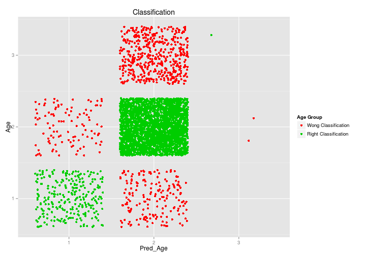

```r
ggplot(newdata, aes(x = Pred_Age, y = Age, colour = factor(Pred_Age == Age))) +
    geom_point(position = "jitter") + scale_colour_manual("Age Group", values = c("2",
    "3"), labels = c("Wong Classification", "Right Classification")) + ggtitle("Classification")
```

Plot the Predicted Probability for different age group

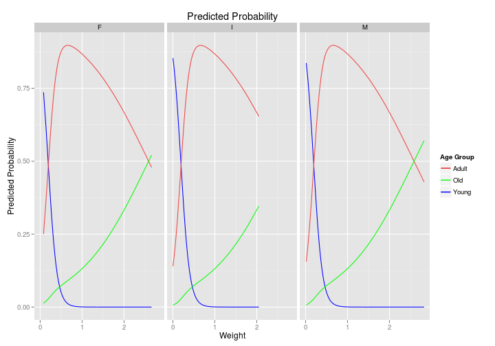

```r
cols <- c(Young = "blue", Adult = "#f04546", Old = "green")
ggplot(newdata, aes(x = Weight)) + geom_line(aes(y = Pred_Prob.1, colour = "Young")) +
    geom_line(aes(y = Pred_Prob.2, colour = "Adult")) + geom_line(aes(y = Pred_Prob.3,
    colour = "Old")) + ylab("Predicted Probability") + facet_wrap(~Sex, ncol = 3) +
    scale_colour_manual("Age Group", values = cols) + ggtitle("Predicted Probability")
```

#### From the graph, we can tell that prediction for Young group should be good,but it may difficult to distinguish Old and Adult when Weight is heavy.

#### It seems that more Sex I abalone is mis-classified to Young and Adult group, but more Sex F abalone is mis-classified to Old grope. And the biggest problem is in Old group. One reason maybe that we adopt linear combination of variables in multinational regression instead.

#### How about using Linear Discriminant Analysis?

Only using Whole.weight

```r
LDA1 = lda(Age ~ Whole.weight, yData)
pred1 = predict(LDA1)$class
newdataL1 = with(yData, data.frame(Weight = Whole.weight, Sex = Sex, Age = Age,
    Pred_Age1 = pred1))
Data_misL1 = subset(newdataL1, Age != Pred_Age1)
```

```r
LDA2 = lda(Age ~ ., yData)
pred2 = predict(LDA2)$class
newdataL2 = with(yData, data.frame(Weight = Whole.weight, Sex = Sex, Age = Age,
    Pred_Age2 = pred2))
Data_misL2 = subset(newdataL2, Age != Pred_Age2)
```

Plot the graph:

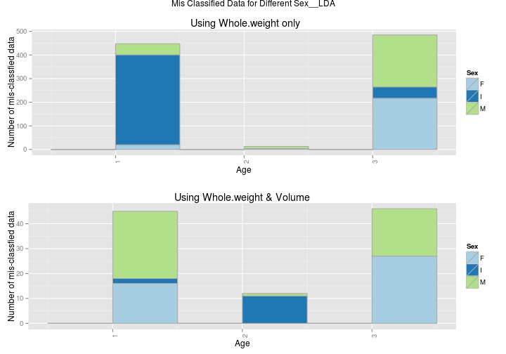

```r
p1 = ggplot(Data_misL1, aes(x = Age, fill = Sex)) + geom_bar(binwidth = 1/2,
    color = "darkgrey") + ylab("Number of mis-classfied data") + ggtitle(" Using Whole.weight only") +
    theme(axis.text.x = element_text(angle = 90)) + scale_fill_brewer("Sex",
    type = "qual", palette = 3)
p2 = ggplot(Data_misL2, aes(x = Age, fill = Sex)) + geom_bar(binwidth = 1/2,
    color = "darkgrey") + ylab("Number of mis-classfied data") + ggtitle("Using Whole.weight & Volume") +
    theme(axis.text.x = element_text(angle = 90)) + scale_fill_brewer("Sex",
    type = "qual", palette = 3)
grid.arrange(p1, p2, main = "Mis Classified Data for Different Sex__LDA")
```

Only use Volume

```r
LDA3 = lda(Age ~ Volume, yData)
pred3 = predict(LDA3)$class
newdataL3 = with(yData, data.frame(Weight = Whole.weight, Sex = Sex, Age = Age,
    Pred_Age3 = pred3))
Data_misL3 = subset(newdataL3, Age != Pred_Age3)
```

Plot the graph:

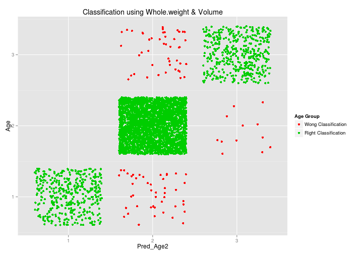

```r
ggplot(newdataL2, aes(x = Pred_Age2, y = Age, colour = factor(Pred_Age2 == Age))) +
    geom_point(position = "jitter") + scale_colour_manual("Age Group", values = c("2",
    "3"), labels = c("Wong Classification", "Right Classification")) + ggtitle("Classification using Whole.weight & Volume")
```

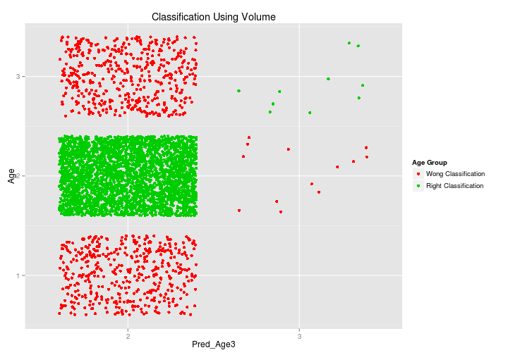

```r
ggplot(newdataL3, aes(x = Pred_Age3, y = Age, colour = factor(Pred_Age3 == Age))) +
    geom_point(position = "jitter") + scale_colour_manual("Age Group", values = c("2",
    "3"), labels = c("Wong Classification", "Right Classification")) + ggtitle("Classification Using Volume")
```

#### The answer is NO. Using Volume and Whole.weight separately will not give a good classification.

#### Then, which variable is more important, Length, Diameter, Height, or Whole.weight? We do not want to consider Volume now because this measure can not be obtained directly. So we will go back to above four easily measured variables.

New data frame which record the minimum value and maximum value of each variable.

```r
jData <- ddply(Data, ~Sex + Rings, function(x) {
    jLevels <- c("min", "max")
    Length = range(x$Length)
    Height = range(x$Height)
    Diameter = range(x$Diameter)
    Whole.weight = range(x$Whole.weight)
    return(data.frame(Length, Height, Diameter, Whole.weight, stat = jLevels))
})
```

Plot the graph

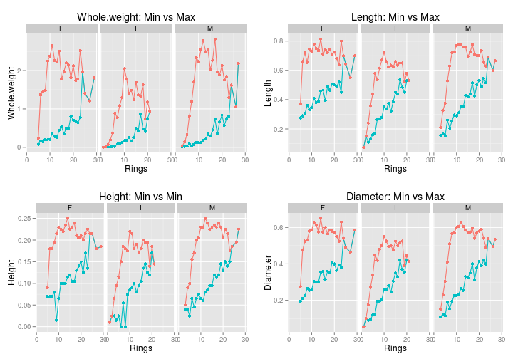

```r
p_Height = ggplot(jData, aes(x = Rings, y = Height, group = stat, colour = stat)) +
    geom_line() + geom_point() + facet_wrap(~Sex, ncol = 3) + ggtitle("Height: Min vs Min") +
    theme(legend.position = "none")
p_Length = ggplot(jData, aes(x = Rings, y = Length, group = stat, colour = stat)) +
    geom_line() + geom_point() + facet_wrap(~Sex, ncol = 3) + ggtitle("Length: Min vs Max") +
    theme(legend.position = "none")
p_Diameter = ggplot(jData, aes(x = Rings, y = Diameter, group = stat, colour = stat)) +
    geom_line() + geom_point() + facet_wrap(~Sex, ncol = 3) + ggtitle("Diameter: Min vs Max") +
    theme(legend.position = "none")
p_Whole.weight = ggplot(jData, aes(x = Rings, y = Whole.weight, group = stat,
    colour = stat)) + geom_line() + geom_point() + facet_wrap(~Sex, ncol = 3) +
    ggtitle("Whole.weight: Min vs Max")

tmp <- ggplot_gtable(ggplot_build(p_Whole.weight))
leg <- which(sapply(tmp$grobs, function(x) x$name) == "guide-box")
legend <- tmp$grobs[[leg]]

grid.arrange(arrangeGrob(p_Whole.weight + theme(legend.position = "none"), p_Length,
    p_Height, p_Diameter))
```

Try the similar thing in xyplot

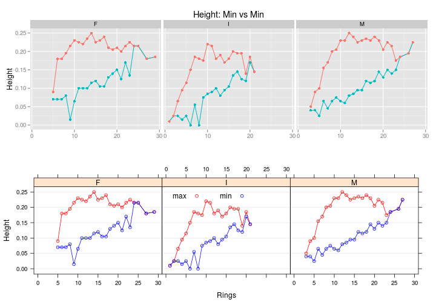

```r
px_Height = xyplot(Height ~ Rings | Sex, jData, group = stat, auto.key = list(columns = 2,
    x = 0.35, y = 0.85, corner = c(0, 1)), type = c("p", "l"), par.settings = list(superpose.line = list(col = c("red",
    "blue")), superpose.symbol = list(col = c("red", "blue"))), grid = "h")
grid.arrange(arrangeGrob(p_Height + xlab(""), px_Height))
```

#### From the graph above, we can see that Whole.weight and Height share the similar trend of range, while Length and Diameter share similar trend of range. Does it mean Whole.weight is more close related to Height, and Length is more related to Diameter?

#### Regression.

```r
jFun <- function(x) {
    name = c()
    Coefs = c()
    for (i in 1:4) {
        temp = c()
        temp <- rbind(temp, as.numeric(coef(lm(x[, i + 1] ~ Rings, x))))
        Coefs = rbind(Coefs, temp)
        name = rbind(name, names(x[i + 1]))
    }
    return(data.frame(Intercept = Coefs[, 1], Slope = Coefs[, 2], Variable = name))
}
jCoefs <- ddply(Data, ~Sex, jFun)

foo <- ddply(jCoefs, ~Variable, function(x) {
    lerange <- c(which.min(x$Intercept), which.max(x$Intercept))
    cbind(x[lerange, c("Variable", "Sex", "Intercept", "Slope")], stat = c("min_slope",
        "max_slope"))
})
foo = xtable(foo)
print(foo, type = "html", include.rownames = FALSE)
```

[output not shown]

Plot the regression line of Height

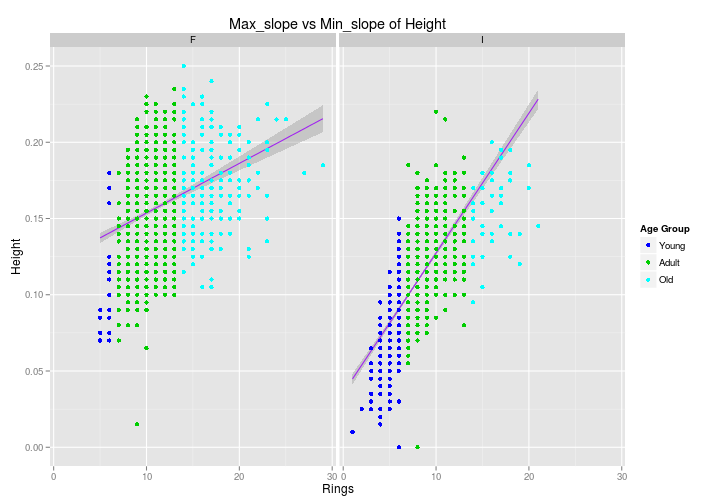

```r
ggplot(subset(Data, Sex %in% c("F", "I")), aes(x = Rings, y = Height)) + facet_wrap(~Sex,
    ncol = 2) + geom_smooth(method = "lm", colour = "purple") + geom_point(aes(colour = factor(Age))) +
    ggtitle("Max_slope vs Min_slope of Height") + scale_colour_manual("Age Group",
    values = c("4", "3", "5"), labels = c("Young", "Adult", "Old"))
```

Plot the regression line of Diameter

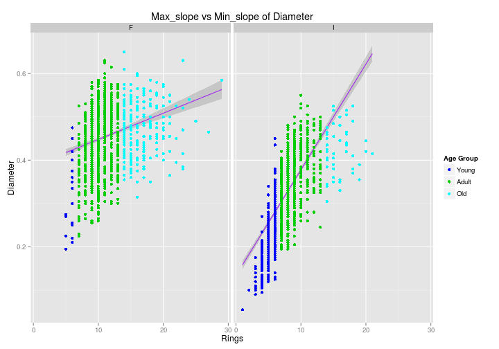

```r
ggplot(subset(Data, Sex %in% c("F", "I")), aes(x = Rings, y = Diameter)) + facet_wrap(~Sex,
    ncol = 2) + geom_smooth(method = "lm", colour = "purple") + geom_point(aes(colour = factor(Age))) +
    ggtitle("Max_slope vs Min_slope of Diameter") + scale_colour_manual("Age Group",
    values = c("4", "3", "5"), labels = c("Young", "Adult", "Old"))
```

Plot the regression line of Length

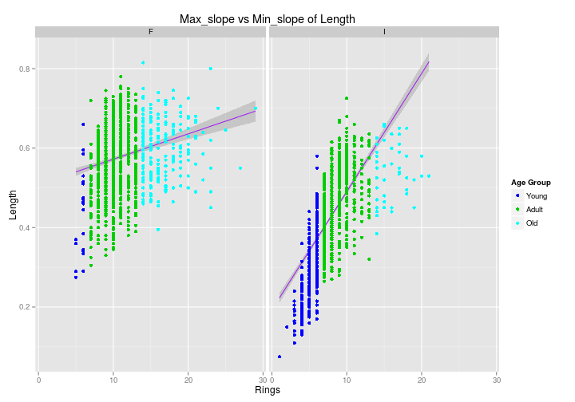

```r
ggplot(subset(Data, Sex %in% c("F", "I")), aes(x = Rings, y = Length)) + facet_wrap(~Sex,
    ncol = 2) + geom_smooth(method = "lm", colour = "purple") + geom_point(aes(colour = factor(Age))) +
    ggtitle("Max_slope vs Min_slope of Length") + scale_colour_manual("Age Group",
    values = c("4", "3", "5"), labels = c("Young", "Adult", "Old"))
```

Plot the regression line of Whole.weight

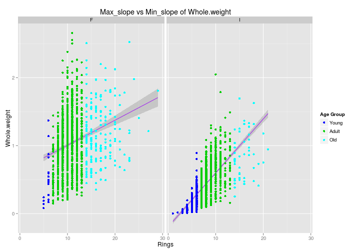

```r
ggplot(subset(Data, Sex %in% c("F", "I")), aes(x = Rings, y = Whole.weight)) +
    facet_wrap(~Sex, ncol = 2) + geom_smooth(method = "lm", colour = "purple") +
    geom_point(aes(colour = factor(Age))) + ggtitle("Max_slope vs Min_slope of Whole.weight") +
    scale_colour_manual("Age Group", values = c("4", "3", "5"), labels = c("Young",
        "Adult", "Old"))
```